# Simulando

Grupo

02-12-2024

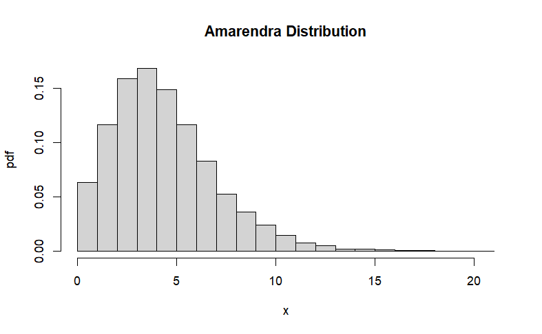

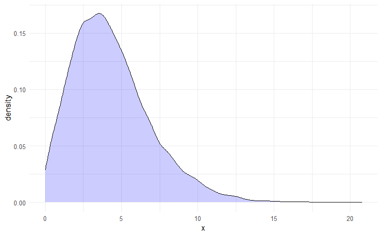

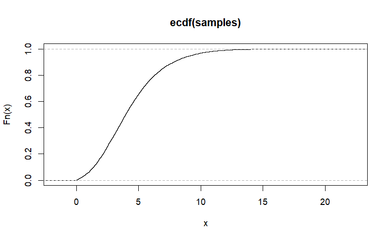

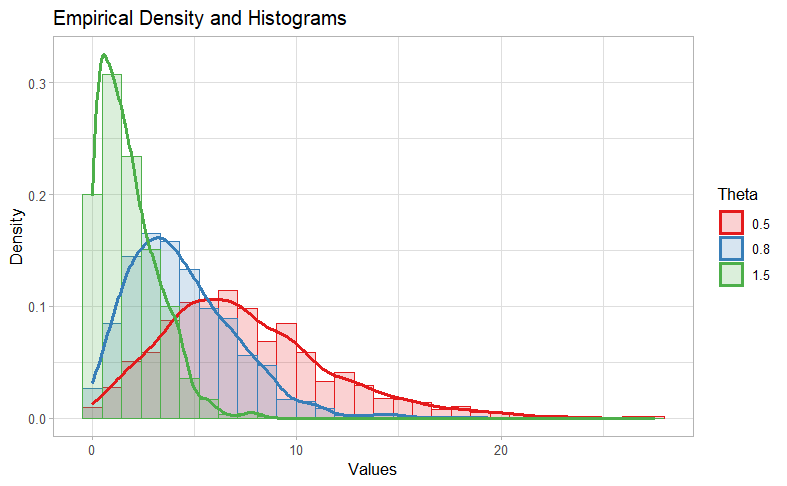

### Monte carlo simulation

|  | Parameter | SampleSize | MLE_mean | Bias | MSE | PC |
| --- | --- | --- | --- | --- | --- | --- |
| 25 | 0.1 | 25 | 0.10101951 | 1.019513e-03 | 9.398587e-05 | 0.968 |
| 50 | 0.1 | 50 | 0.10067780 | 6.778023e-04 | 5.190720e-05 | 0.958 |
| 100 | 0.1 | 100 | 0.10001714 | 1.714286e-05 | 2.515684e-05 | 0.945 |
| 200 | 0.1 | 200 | 0.09993318 | -6.682313e-05 | 1.233579e-05 | 0.956 |
| 400 | 0.1 | 400 | 0.09999735 | -2.653367e-06 | 6.634747e-06 | 0.940 |

|  | Parameter | SampleSize | MLE_mean | Bias | MSE | PC |
| --- | --- | --- | --- | --- | --- | --- |
| 25 | 0.5 | 25 | 0.5045065 | 0.0045065488 | 0.0027610862 | 0.944 |
| 50 | 0.5 | 50 | 0.5018624 | 0.0018623944 | 0.0012576427 | 0.948 |
| 100 | 0.5 | 100 | 0.5014346 | 0.0014346142 | 0.0006053604 | 0.949 |
| 200 | 0.5 | 200 | 0.5016731 | 0.0016731439 | 0.0003261125 | 0.946 |
| 400 | 0.5 | 400 | 0.5004220 | 0.0004220014 | 0.0001504945 | 0.953 |

|  | Parameter | SampleSize | MLE_mean | Bias | MSE | PC |
| --- | --- | --- | --- | --- | --- | --- |
| 25 | 1 | 25 | 1.010440 | 0.0104402591 | 0.0096370903 | 0.959 |
| 50 | 1 | 50 | 1.004827 | 0.0048267941 | 0.0050072668 | 0.942 |
| 100 | 1 | 100 | 1.003562 | 0.0035620133 | 0.0020315334 | 0.968 |
| 200 | 1 | 200 | 1.001197 | 0.0011969160 | 0.0011241625 | 0.951 |
| 400 | 1 | 400 | 1.000479 | 0.0004793773 | 0.0005864435 | 0.954 |

|  | Parameter | SampleSize | MLE_mean | Bias | MSE | PC |
| --- | --- | --- | --- | --- | --- | --- |
| 25 | 1.5 | 25 | 1.509498 | 0.009498480 | 0.020311232 | 0.964 |
| 50 | 1.5 | 50 | 1.507548 | 0.007547884 | 0.011664530 | 0.943 |
| 100 | 1.5 | 100 | 1.504007 | 0.004007144 | 0.005248537 | 0.953 |
| 200 | 1.5 | 200 | 1.502374 | 0.002373855 | 0.002908769 | 0.946 |
| 400 | 1.5 | 400 | 1.498882 | -0.001118354 | 0.001255284 | 0.953 |

|  | Parameter | SampleSize | MLE_mean | Bias | MSE | PC |
| --- | --- | --- | --- | --- | --- | --- |
| 25 | 3 | 25 | 3.047800 | 0.047799777 | 0.131382611 | 0.950 |
| 50 | 3 | 50 | 3.029002 | 0.029002164 | 0.067212177 | 0.940 |
| 100 | 3 | 100 | 3.021001 | 0.021000616 | 0.033429433 | 0.948 |
| 200 | 3 | 200 | 3.008724 | 0.008724484 | 0.015799742 | 0.947 |
| 400 | 3 | 400 | 3.002626 | 0.002625893 | 0.008122609 | 0.941 |

|  | Parameter | SampleSize | MLE_mean | Bias | MSE | PC |
| --- | --- | --- | --- | --- | --- | --- |
| 25 | 5 | 25 | 5.143073 | 0.14307299 | 0.60075624 | 0.953 |
| 50 | 5 | 50 | 5.080382 | 0.08038220 | 0.29324710 | 0.953 |
| 100 | 5 | 100 | 5.052471 | 0.05247098 | 0.14831416 | 0.947 |
| 200 | 5 | 200 | 5.025433 | 0.02543349 | 0.06504191 | 0.954 |
| 400 | 5 | 400 | 5.018757 | 0.01875704 | 0.03180272 | 0.957 |

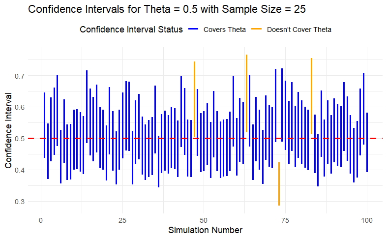

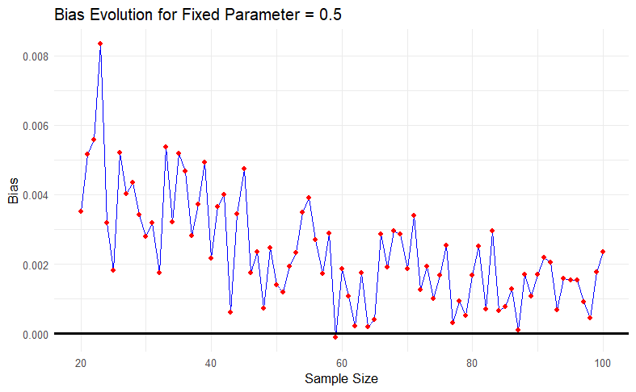

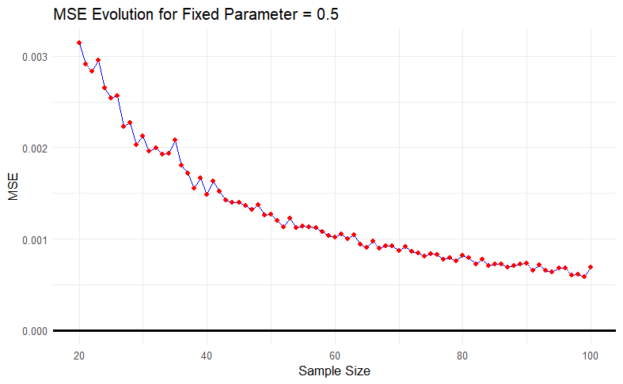

## Plotting

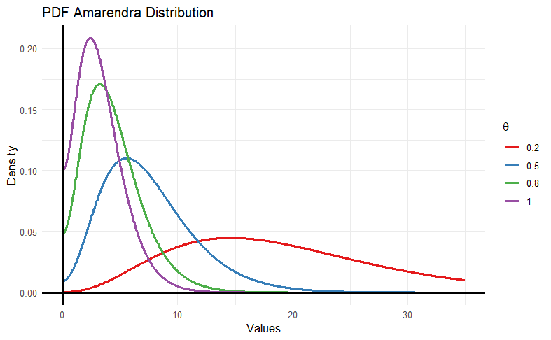

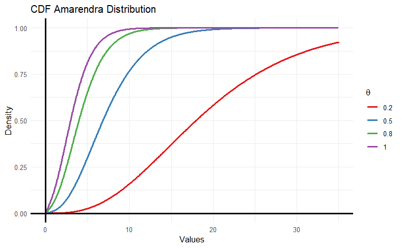

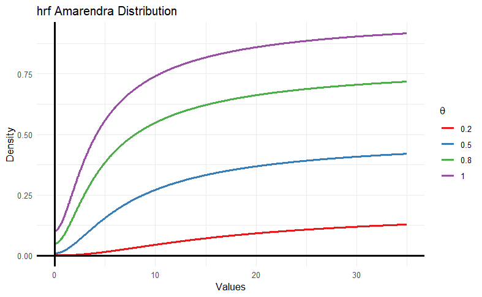

## Theoretical model fitting

Best model with lowest, W, A, KS, -loglike

1. Amarendra (AMAR) - “famarendra”
2. GeneralizedHL(GHL) - “fehl”
3. Lindley(Li) - “flind”
4. InverseLindley(ILi) - “filind”
5. Exponential(Exp) - “fexp”

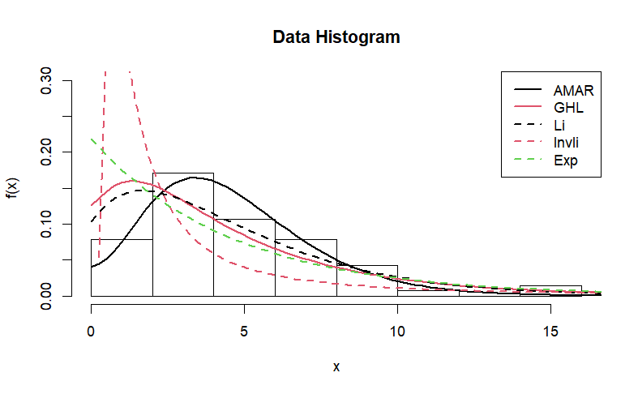

| Distributions | MLE | SEs | neg_loglike | A. | W. | KS | p.value |
| --- | --- | --- | --- | --- | --- | --- | --- |
| Amarendra | 0.7685547 | 0.04466910 | 167.7997 | 0.2098030 | 0.02426659 | 0.04985396 | 9.915281e-01 |
| GHL | 0.2515625 | 0.03006699 | 172.3515 | 0.7937926 | 0.10946747 | 0.15901088 | 5.170861e-02 |
| Li | 0.3764648 | 0.03242908 | 170.0783 | 0.5900627 | 0.07777812 | 0.12548402 | 2.025175e-01 |
| InvLi | 1.8515625 | 0.17614976 | 226.9207 | 9.3246300 | 1.68387599 | 0.38399907 | 8.528673e-10 |
| Exp | 0.2180664 | 0.02606337 | 176.6187 | 0.9576871 | 0.13377188 | 0.20547316 | 4.545390e-03 |

| Distributions | MLE | AIC | BIC | CAIC | HQIC |
| --- | --- | --- | --- | --- | --- |
| Amarendra | 0.7685547 | 337.5994 | 339.8478 | 337.6582 | 338.4925 |
| GHL | 0.2515625 | 346.7029 | 348.9514 | 346.7617 | 347.5960 |
| Li | 0.3764648 | 342.1565 | 344.4050 | 342.2154 | 343.0497 |
| InvLi | 1.8515625 | 455.8414 | 458.0899 | 455.9002 | 456.7345 |
| Exp | 0.2180664 | 355.2375 | 357.4860 | 355.2963 | 356.1306 |

## Real-life data fitting

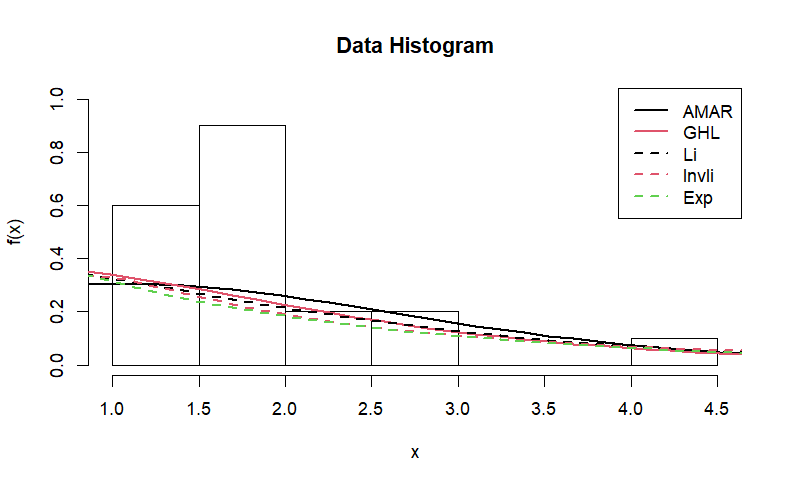

| Distributions | MLE | SEs | neg_loglike | A. | W. | KS | p.value |
| --- | --- | --- | --- | --- | --- | --- | --- |
| Amarendra | 1.4808594 | 0.1606340 | 27.81933 | 0.8304256 | 0.14064227 | 0.3356229 | 0.022091457 |
| GHL | 0.7314453 | 0.1635558 | 29.46407 | 0.6765949 | 0.11430746 | 0.3981582 | 0.003524379 |
| Li | 0.8162109 | 0.1361092 | 30.24955 | 0.6758089 | 0.11408848 | 0.3911267 | 0.004400415 |
| InvLi | 2.2531250 | 0.4086067 | 31.75720 | 0.2711967 | 0.04666902 | 0.3691846 | 0.008576384 |
| Exp | 0.5262695 | 0.1176770 | 32.83708 | 0.6243490 | 0.10537410 | 0.4394834 | 0.000882563 |

| Distributions | MLE | AIC | BIC | CAIC | HQIC |
| --- | --- | --- | --- | --- | --- |
| Amarendra | 1.4808594 | 57.63866 | 58.63440 | 57.86089 | 57.83304 |
| GHL | 0.7314453 | 60.92814 | 61.92387 | 61.15036 | 61.12252 |
| Li | 0.8162109 | 62.49910 | 63.49483 | 62.72132 | 62.69348 |
| InvLi | 2.2531250 | 65.51440 | 66.51013 | 65.73662 | 65.70878 |
| Exp | 0.5262695 | 67.67416 | 68.66989 | 67.89638 | 67.86853 |

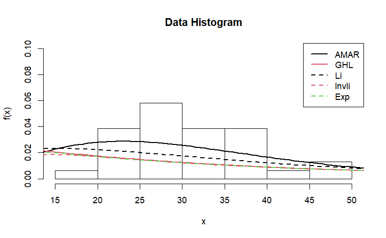

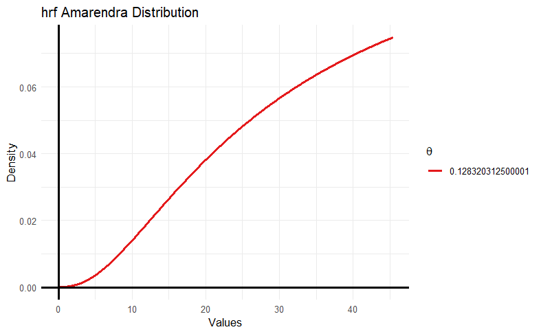

| Distributions | MLE | SEs | neg_loglike | A. | W. | KS | p.value |
| --- | --- | --- | --- | --- | --- | --- | --- |
| Amarendra | 0.12832031 | 0.011515546 | 116.7044 | 0.4261033 | 0.07781401 | 0.2572687 | 2.686406e-02 |
| GHL | 0.03322266 | 0.005961553 | 136.5591 | 0.4219385 | 0.07729474 | 0.4550105 | 2.197990e-06 |
| Li | 0.06328125 | 0.008041840 | 126.9949 | 0.4273815 | 0.07796353 | 0.3676702 | 2.888555e-04 |
| InvLi | 30.15000000 | 5.251751362 | 137.2461 | 0.3922370 | 0.07400359 | 0.4744295 | 6.265946e-07 |
| Exp | 0.03246826 | 0.005825934 | 137.2644 | 0.4242180 | 0.07757819 | 0.4587585 | 1.733904e-06 |

| Distributions | MLE | AIC | BIC | CAIC | HQIC |
| --- | --- | --- | --- | --- | --- |
| Amarendra | 0.12832031 | 235.4087 | 236.8427 | 235.5466 | 235.8762 |
| GHL | 0.03322266 | 275.1182 | 276.5522 | 275.2561 | 275.5856 |
| Li | 0.06328125 | 255.9897 | 257.4237 | 256.1277 | 256.4572 |
| InvLi | 30.15000000 | 276.4922 | 277.9262 | 276.6301 | 276.9597 |
| Exp | 0.03246826 | 276.5289 | 277.9629 | 276.6668 | 276.9963 |

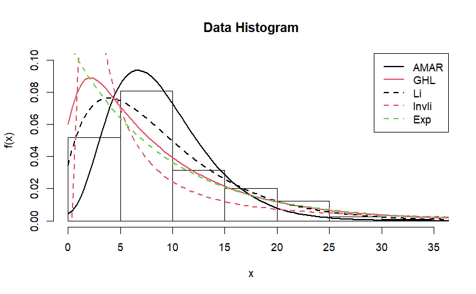

| Distributions | MLE | SEs | neg_loglike | A. | W. | KS | p.value |
| --- | --- | --- | --- | --- | --- | --- | --- |
| Amarendra | 0.4231445 | 0.013884148 | 724.5125 | 0.5076698 | 0.08397187 | 0.09763777 | 2.588830e-02 |
| GHL | 0.1201172 | 0.007954404 | 719.6714 | 1.1274179 | 0.16349644 | 0.16149717 | 1.367498e-05 |
| Li | 0.2039062 | 0.009617776 | 706.8255 | 0.6765742 | 0.10438901 | 0.09020495 | 4.893271e-02 |
| InvLi | 4.1515625 | 0.236585799 | 816.0092 | 18.0915482 | 3.13199898 | 0.26328264 | 3.745092e-14 |
| Exp | 0.1114258 | 0.007378758 | 728.3946 | 1.0230308 | 0.14853470 | 0.18578496 | 2.920994e-07 |

| Distributions | MLE | AIC | BIC | CAIC | HQIC |
| --- | --- | --- | --- | --- | --- |
| Amarendra | 0.4231445 | 1451.025 | 1454.454 | 1451.043 | 1452.409 |
| GHL | 0.1201172 | 1441.343 | 1444.772 | 1441.361 | 1442.727 |
| Li | 0.2039062 | 1415.651 | 1419.080 | 1415.669 | 1417.035 |
| InvLi | 4.1515625 | 1634.018 | 1637.448 | 1634.036 | 1635.402 |
| Exp | 0.1114258 | 1458.789 | 1462.219 | 1458.807 | 1460.173 |

## MCMC estudo convergência

### Priori Gama pouco informativa

Priori $\theta \sim \Gamma(\alpha,\beta)$ pouco informativa, basta alterar os hiperparâmetros alfa e beta da priori na função AMHtheta

### Priori Jeffreys

Com um tamanho amostral N menor, para verificar convergência quando a verossimilhança não domina a priori totalmente. Algoritmo extremamente sensível ao chute inicial e a mudanças no tamanho amostral.

## MCMC estudo simulação

### Priori Empirica

Pode-se utilizar os dados para obter os hiperparâmetros da distribuição a priori. Integrando $\theta$ da distribuição conjunta de $y$ e $\theta$, obtém-se uma forma de verossimilhança para os hiperparâmetros $\alpha$ e $\beta$ da priori elicitada $\theta \sim \Gamma(\alpha,\beta)$. Assim, obtém-se as estimativas de máxima verossimilhança para $\alpha$ e $\beta$. Como a integral abaixo não possui forma analítica, primeiro, integra-se numericamente a expressão em função de $\theta$ e, por último, maximiza-se a expressão com um otimizador.

$$\int_{0}^{\infty} f(y \mid\theta)\pi(\theta) d\theta
=\frac{\beta^\alpha}{\Gamma(\alpha)}
(1 + x + x^2 + x^3)
\int_0^\infty \frac{\theta^{\alpha+3} e^{-\theta (x + \beta)}}{\theta^3
+ \theta^2 + 2\theta + 6} \, d\theta
= f(y \mid \alpha, \beta)$$